# Linear Regression

Rene Essomba

2020-05-14

# A1. Simple Linear Regression

## 1. Estimated Simple Regression Equation ([link](http://www.r-tutor.com/elementary-statistics/simple-linear-regression))

If we choose the parameters $\alpha$ and $\beta$ in the simple linear regression model so as to minimize the sum of squares of the error term $\epsilon$, we will have the so-called **estimated simple regression equation**. It allows us to compute **fitted values** of *y* based on values of *x*.
$$\hat{y} = ax + b$$

### Problem

Apply the simple linear regression model for the data set faithful, and estimate the next eruption duration if the waiting time since the last eruption has been 80 minutes.

### Solution

We apply the `lm` function to a formula that describes the variable `eruptions` by the variable `waiting`, and save the linear regression model in a new variable `eruption.lm`.

```r
eruption.lm = lm(eruptions ~ waiting, data = faithful)
```

Then we extract the parameters of the estimated regression equation with the coefficients function.

```r
coeffs = coefficients(eruption.lm)
coeffs
```

```
## (Intercept)     waiting
## -1.87401599  0.07562795
```

We now fit the eruption duration using the estimated regression equation

```r
waiting = 80  # waiting time
duration = coeffs[1] + coeffs[2]*waiting
duration
```

```
## (Intercept)
##     4.17622
```

### Answer

Based on the simple linear regression model, if the waiting time since the last eruption has been 80 minutes, we expect the next one to last 4.1762 minutes.

### Alternative Solution

We wrap the waiting parameter value inside a new data frame named newdata.

```r
newdata = data.frame(waiting = 80) # wrap the parameter
```

Then we apply the predict function to eruption.lm along with newdata

```r
predict(eruption.lm, newdata) # apply predict
```

```
##       1
## 4.17622
```

## 2. Coefficient of Determination

The coefficient of determination of a linear regression model is the quotient of the variances of the fitted values and observed values of the dependent variable. If we denote $y_i$ as the observed values of the dependent variable, $\bar{y}$ as its mean, and $\hat{y}_i$ as the fitted value, then the coefficient of determination is:
$$\frac{\sum\left(\hat{y}_i - \bar{y}\right)^2}{\sum\left(y_i - \bar{y}\right)^2}$$

### Problem

Find the coefficient of determination for the simple linear regression model of the data set faithful.

### Solution

We apply the `lm` function to a formula that describes the variable `eruptions` by the variable `waiting`, and save the linear regression model in a new variable `eruption.lm`.

```r
eruption.lm = lm(eruptions ~ waiting, data = faithful)
```

Then we extract the coefficient of determination from the r.squared attribute of its summary.

```r
summary(eruption.lm)$r.squared
```

```
## [1] 0.8114608
```

### Answer

The coefficient of determination of the simple linear regression model for the data set faithful is $0.8114608$

### Note

Further detail of the `r.squared attribute` can be found in the R documentation.

```r
help(summary.lm)
```

## 3. Significance Test for Linear Regression

Assume that the error term $\epsilon$ in the linear regression model is independent of $x$, and is normally distributed, with zero mean and constant variance. We can decide whether there is any significant relationship between $x$ and $y$ by testing the null hypothesis that $\beta = 0$.

### Problem

Decide whether there is a significant relationship between the variables in the linear regression model of the data set faithful at .05 significance level.

### Solution

We apply the `lm` function to a formula that describes the variable `eruptions` by the variable `waiting`, and save the linear regression model in a new variable `eruption.lm`.

```r
eruption.lm = lm(eruptions ~ waiting, data = faithful)
```

Then we print out the F-statistics of the significance test with the summary function

```r
summary(eruption.lm)
```

```
##
## Call:
## lm(formula = eruptions ~ waiting, data = faithful)
##
## Residuals:
##      Min       1Q   Median       3Q      Max
## -1.29917 -0.37689  0.03508  0.34909  1.19329
##
## Coefficients:
##              Estimate Std. Error t value Pr(>|t|)
## (Intercept) -1.874016   0.160143  -11.70   <2e-16 ***
## waiting      0.075628   0.002219   34.09   <2e-16 ***
## ---
## Signif. codes:  0 '***' 0.001 '**' 0.01 '*' 0.05 '.' 0.1 ' ' 1
##
## Residual standard error: 0.4965 on 270 degrees of freedom
## Multiple R-squared:  0.8115, Adjusted R-squared:  0.8108
## F-statistic:  1162 on 1 and 270 DF,  p-value: < 2.2e-16
```

### Answer

As the p-value is much less than 0.05, we reject the null hypothesis that $\beta = 0$. Hence there is a significant relationship between the variables in the linear regression model of the data set faithful.

### Note

Further detail of the `summary` function for linear regression model can be found in the R documentation.

```r
help(summary.lm)
```

## 4. Confidence Interval for Linear Regression

Assume that the error term $\epsilon$ in the linear regression model is independent of $x$, and is normally distributed, with zero mean and constant variance. For a given value of $x$, the interval estimate for the mean of the dependent variable, $\bar{y}$ , is called the **confidence interval**.

### Problem

In the data set faithful, develop a 95% confidence interval of the mean eruption duration for the waiting time of 80 minutes.

### Solution

We apply the `lm` function to a formula that describes the variable `eruptions` by the variable `waiting`, and save the linear regression model in a new variable `eruption.lm`.

```r
attach(faithful) # attach the data frame
eruption.lm = lm(eruptions ~ waiting)
```

Then we create a new data frame that set the waiting time value.

```r
newdata = data.frame(waiting=80)
```

We now apply the predict function and set the predictor variable in the newdata argument. We also set the interval type as “confidence”, and use the default 0.95 confidence level.

```r
predict(eruption.lm, newdata, interval = "confidence")
```

```
##       fit      lwr      upr
## 1 4.17622 4.104848 4.247592
```

```r
detach(faithful) # clean up
```

### Answer

The 95% confidence interval of the mean eruption duration for the waiting time of 80 minutes is between 4.1048 and 4.2476 minutes.

### Note

Further detail of the `predict` function for linear regression model can be found in the R documentation.

```r
help("predict.lm")
```

## 5. Prediction Interval for Linear Regression

Assume that the error term $\epsilon$ in the linear regression model is independent of $x$, and is normally distributed, with zero mean and constant variance. For a given value of $x$, the interval estimate for the dependent variable, $y$ is called the **prediction interval**.

### Problem

In the data set faithful, develop a 95% prediction interval of the eruption duration for the waiting time of 80 minutes.

### Solution

We apply the `lm` function to a formula that describes the variable `eruptions` by the variable `waiting`, and save the linear regression model in a new variable `eruption.lm`.

```r
attach(faithful) # attach the data frame
eruption.lm = lm(eruptions ~ waiting)
```

Then we create a new data frame that set the waiting time value.

```r
newdata = data.frame(waiting=80)
```

```r
predict(eruption.lm, newdata, interval = "predict")
```

```
##       fit      lwr      upr
## 1 4.17622 3.196089 5.156351
```

```r
detach(faithful) # clean up
```

### Answer

The 95% prediction interval of the eruption duration for the waiting time of 80 minutes is between 3.1961 and 5.1564 minutes.

### Note

Further detail of the `predict` function for linear regression model can be found in the R documentation.

```r
help("predict.lm")
```

## 6. Residual Plot

The residual data of the simple linear regression model is the difference between the observed data of the dependent variable $y$ and the fitted values $\hat{y}$.
$$Residual = y - \hat{y}$$

### Problem

Plot the residual of the simple linear regression model of the data set faithful against the independent variable waiting.

### Solution

We apply the `lm` function to a formula that describes the variable `eruptions` by the variable `waiting`, and save the linear regression model in a new variable `eruption.lm`. Then we compute the residual with the `resid` function.

```r
eruption.lm = lm(eruptions ~ waiting, data = faithful)
eruption.es = resid(eruption.lm)
```

We now plot the residual against the observed values of the variable waiting.

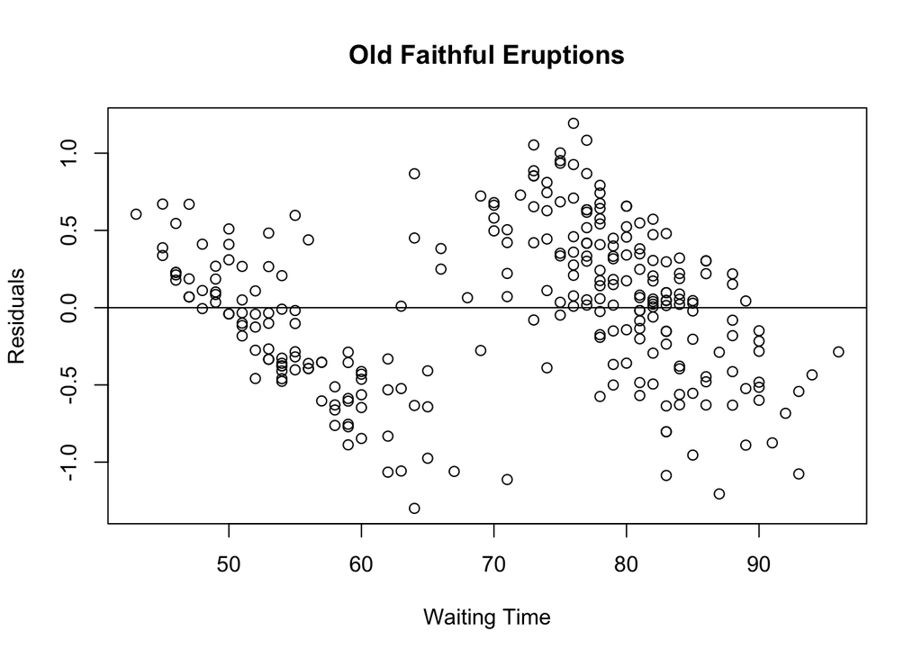

```r
plot(faithful$waiting, eruption.es,
     ylab = "Residuals", xlab = "Waiting Time",
     main = "Old Faithful Eruptions")
abline(0, 0) # horizon
```

### Note

Further detail of the `resid` function for linear regression model can be found in the R documentation.

```r
help("resid")
```

## 7. Standardized Residual

The **standardized residual** is the residual divided by its standard deviation.
$$\text{Standardized Residual}_i = \frac{Residual_i}{\text{Standard Deviation of Residual}_i}$$

### Problem

Plot the standardized residual of the simple linear regression model of the data set faithful against the independent variable waiting.

### Solution

We apply the `lm` function to a formula that describes the variable `eruptions` by the variable `waiting`, and save the linear regression model in a new variable `eruption.lm`. Then we compute the standardized residual with the `rstandard` function.

```r
eruption.lm = lm(eruptions ~ waiting, data = faithful)
eruption.stdres = rstandard(eruption.lm)
```

We now plot the standardized residual against the observed values of the variable waiting.

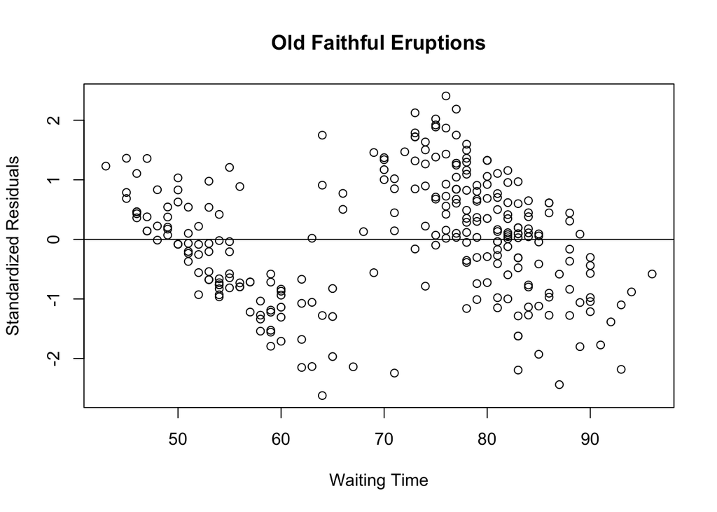

```r
plot(faithful$waiting, eruption.stdres,
     ylab = "Standardized Residuals",
     xlab = "Waiting Time",
     main = "Old Faithful Eruptions")
abline(0, 0) # horizon
```